# **Le marché des véhicules électriques**

L'analyse de la taille du marché est un aspect crucial des études de marché. Elle permet de déterminer le volume de ventes potentiel d'un marché donné. Elle aide les entreprises à comprendre l'ampleur de la demande, à évaluer les niveaux de saturation du marché et à identifier les opportunités de croissance.

🎯 **Objectif**:

L'objectif principal de cette analyse est d'exploiter les données historiques d'immatriculation des véhicules électriques afin de comprendre leur pénétration actuelle sur le marché, de prédire leur croissance future et d'identifier les principales tendances et facteurs d'expansion.

## Les données

L'ensemble de données fourni contient les colonnes suivantes, chacune représentant différents aspects de la population de véhicules électriques (VE) aux États-Unis :

- **VIN (1-10)** : Numéro d'identification partiel du véhicule.
- **County** (Comté) : Le comté dans lequel le véhicule est immatriculé.
- **City** (Ville) : La ville dans laquelle le véhicule est immatriculé.
- **State** (État) : État dans lequel le véhicule est immatriculé. Il semble que cet ensemble de données concerne l'État de Washington (WA).
- **Postal Code** (Code postal) : Le code postal où le véhicule est immatriculé.
- **Model Year** (Année du modèle) : l'année du modèle du véhicule.
- **Make** (Marque) : Le fabricant du véhicule.
- **Model** (Modèle) : Le modèle du véhicule.
- **Electric Vehicle Type** (ype de véhicule électrique) : Le type de véhicule électrique, par exemple, véhicule électrique à batterie (BEV).
- **Clean Alternative Fuel Vehicle (CAFV) Eligibility** (Admissibilité aux véhicules à carburant alternatif propre) (CAFV) : Statut d'admissibilité aux programmes de véhicules à carburant alternatif propre.
- **Electric Range** (Autonomie électrique) : l'autonomie maximale du véhicule sur une seule charge (en miles).
- **Base MSRP** (PDSF de base) : le prix de détail suggéré par le fabricant.
- **Legislative District** (District législatif) : Le district législatif où le véhicule est immatriculé.
- **DOL Vehicle ID** (ID du véhicule DOL) : Identification du véhicule du Département des licences.
- **Vehicle Location** (Localisation du véhicule) : Coordonnées géographiques de l'emplacement du véhicule.
- **Electric Utility** (Fournisseur d'électricité) : Le fournisseur de services d'électricité pour l'emplacement du véhicule.
- **2020 Census Tract** (Secteur de recensement de 2020) : Secteur de recensement où se trouve le véhicule.

Nous avons des colonnes comme `Electric Range` et `Base MSRP` qui contiennent des valeurs null `0.0` que nous conservons pour ne pas perdre des données important pour notre analyse du marché.

### **Question 1** : Analysez la croissance de la population de VE par année modèle.

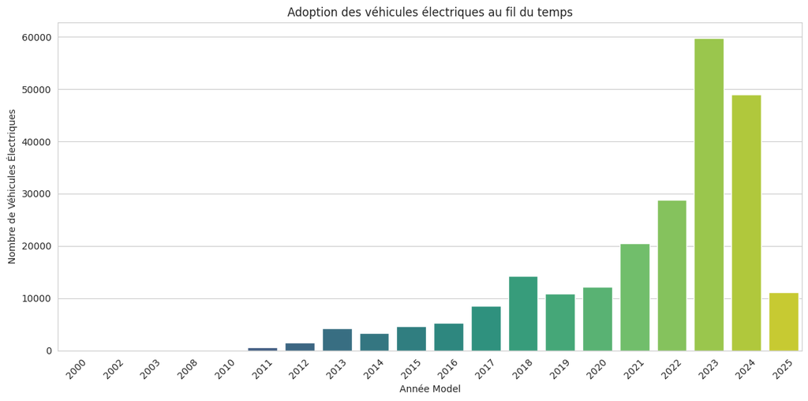

D’après le graphique à barres ci-dessus, il est clair que l’adoption des VE a augmenté au fil du temps, en particulier en notant une tendance à la hausse significative à partir de 2016 environ. Le nombre de véhicules immatriculés augmente modestement jusqu’à ce moment-là, puis commence à augmenter plus rapidement à partir de 2017. L’année 2023 montre une augmentation particulièrement forte du nombre de VE enregistrés, la barre pour 2023 étant la plus haute sur le graphique, indiquant un pic d’adoption des VE.